# Example for loading data with read_csv and ploting some variables

F.A. Barrios

7/13/2019

# Examples Chap02

Chapter 2 examples and `tidy` examples for manipulating data/

## Introduction

We will start in the Chapter 2 of the book: Regression methods in biostatistics: linear, logistic, survival, and repeated measures models, Vittinghoff et al. The first example to load a dataset is using the The western collaborative group study (WCGS). We will use tidyverse tools to load (read_csv) and visualize (ggplot).

Next we set the working directory to load data files, using `setwd` pointing to the working directory. And load the `tidyverse` package.

Now we load the WCGS database into `wcgs` varible using the `read_csv` function.

```
## Observations: 3,154
## Variables: 22
## $ age      <dbl> 50, 51, 59, 51, 44, 47, 40, 41, 50, 43, 59, 54, 48, 39,…
## $ arcus    <dbl> 1, 0, 1, 1, 0, 0, 0, 0, 1, 0, 0, 0, 0, 0, 0, 1, 0, 0, 0…
## $ behpat   <chr> "A1", "A1", "A1", "A1", "A1", "A1", "A1", "A1", "A1", "…
## $ bmi      <dbl> 31.32101, 25.32858, 28.69388, 22.14871, 22.31303, 27.11…
## $ chd69    <chr> "No", "No", "No", "No", "No", "No", "No", "No", "No", "…
## $ chol     <dbl> 249, 194, 258, 173, 214, 206, 190, 212, 130, 233, 181, …
## $ dbp      <dbl> 90, 74, 94, 80, 80, 76, 78, 84, 70, 80, 86, 76, 78, 74,…
## $ dibpat   <chr> "Type A", "Type A", "Type A", "Type A", "Type A", "Type…
## $ height   <dbl> 67, 73, 70, 69, 71, 64, 70, 70, 71, 68, 72, 67, 71, 70,…
## $ id       <dbl> 2343, 3656, 3526, 22057, 12927, 16029, 3894, 11389, 126…
## $ lnsbp    <dbl> 4.882802, 4.787492, 5.062595, 4.836282, 4.836282, 4.753…
## $ lnwght   <dbl> 5.298317, 5.257495, 5.298317, 5.010635, 5.075174, 5.062…
## $ ncigs    <dbl> 25, 25, 0, 0, 0, 80, 0, 25, 0, 25, 10, 0, 20, 0, 4, 0, …
## $ sbp      <dbl> 132, 120, 158, 126, 126, 116, 122, 130, 112, 120, 130, …
## $ smoke    <chr> "Yes", "Yes", "No", "No", "No", "Yes", "No", "Yes", "No…
## $ t1       <dbl> -1.6333529, -4.0633659, 0.6397287, 1.1217681, 2.4250107…
## $ time169  <dbl> 1367, 2991, 2960, 3069, 3081, 2114, 2929, 3010, 3104, 2…
## $ typchd69 <dbl> 0, 0, 0, 0, 0, 0, 0, 0, 0, 0, 0, 0, 0, 1, 0, 0, 0, 0, 0…
## $ uni      <dbl> 0.48607379, 0.18595429, 0.72779906, 0.62446356, 0.37897…
## $ weight   <dbl> 200, 192, 200, 150, 160, 158, 162, 160, 195, 187, 206, …
## $ wghtcat  <chr> "170-200", "170-200", "170-200", "140-170", "140-170", …
## $ agec     <chr> "46-50", "51-55", "56-60", "51-55", "41-45", "46-50", "…
```

```
##       age            arcus           behpat               bmi
##  Min.   :39.00   Min.   :0.0000   Length:3154        Min.   :11.19
##  1st Qu.:42.00   1st Qu.:0.0000   Class :character   1st Qu.:22.96
##  Median :45.00   Median :0.0000   Mode  :character   Median :24.39
##  Mean   :46.28   Mean   :0.2985                      Mean   :24.52
##  3rd Qu.:50.00   3rd Qu.:1.0000                      3rd Qu.:25.84
##  Max.   :59.00   Max.   :1.0000                      Max.   :38.95
##                  NA's   :2
##     chd69                chol            dbp            dibpat
##  Length:3154        Min.   :103.0   Min.   : 58.00   Length:3154
##  Class :character   1st Qu.:197.2   1st Qu.: 76.00   Class :character
##  Mode  :character   Median :223.0   Median : 80.00   Mode  :character
##                     Mean   :226.4   Mean   : 82.02
##                     3rd Qu.:253.0   3rd Qu.: 86.00
##                     Max.   :645.0   Max.   :150.00
##                     NA's   :12
##      height            id            lnsbp           lnwght
##  Min.   :60.00   Min.   : 2001   Min.   :4.585   Min.   :4.357
##  1st Qu.:68.00   1st Qu.: 3741   1st Qu.:4.787   1st Qu.:5.043
##  Median :70.00   Median :11406   Median :4.836   Median :5.136
##  Mean   :69.78   Mean   :10478   Mean   :4.850   Mean   :5.128
##  3rd Qu.:72.00   3rd Qu.:13115   3rd Qu.:4.913   3rd Qu.:5.204
##  Max.   :78.00   Max.   :22101   Max.   :5.438   Max.   :5.768
##
##      ncigs           sbp           smoke                 t1
##  Min.   : 0.0   Min.   : 98.0   Length:3154        Min.   :-47.43147
##  1st Qu.: 0.0   1st Qu.:120.0   Class :character   1st Qu.: -1.00337
##  Median : 0.0   Median :126.0   Mode  :character   Median :  0.00748
##  Mean   :11.6   Mean   :128.6                      Mean   : -0.03336
##  3rd Qu.:20.0   3rd Qu.:136.0                      3rd Qu.:  0.97575
##  Max.   :99.0   Max.   :230.0                      Max.   : 47.01623
##                                                    NA's   :39
##     time169        typchd69           uni                weight
##  Min.   :  18   Min.   :0.0000   Min.   :0.0007097   Min.   : 78
##  1st Qu.:2842   1st Qu.:0.0000   1st Qu.:0.2573755   1st Qu.:155
##  Median :2942   Median :0.0000   Median :0.5157779   Median :170
##  Mean   :2684   Mean   :0.1363   Mean   :0.5052159   Mean   :170
##  3rd Qu.:3037   3rd Qu.:0.0000   3rd Qu.:0.7559902   3rd Qu.:182
##  Max.   :3430   Max.   :3.0000   Max.   :0.9994496   Max.   :320
##
##    wghtcat              agec
##  Length:3154        Length:3154
##  Class :character   Class :character
##  Mode  :character   Mode  :character
##
##
##
##
```

The first line of code loads the library for `tidyverse`, then sets the working directory to point at my user and the directory that I have copyed the data from Vittinghoff’s book. Then shows 22 variables in lines (not all the observations) and the summary of the numerical variables, `summary` automatically estimates general statistics for the numerical variables of the dataset.

## Including Plots

```
##    Min. 1st Qu.  Median    Mean 3rd Qu.    Max.
##    98.0   120.0   126.0   128.6   136.0   230.0
```

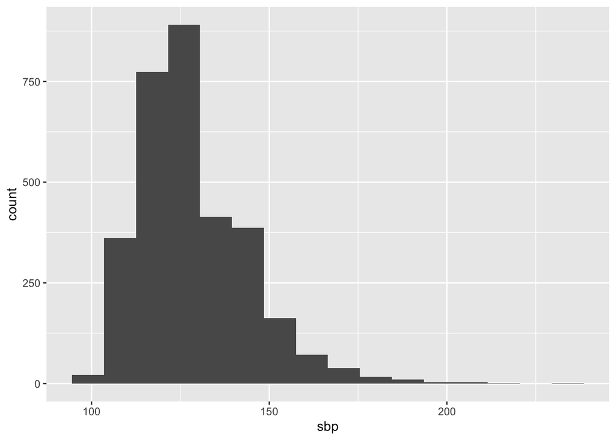

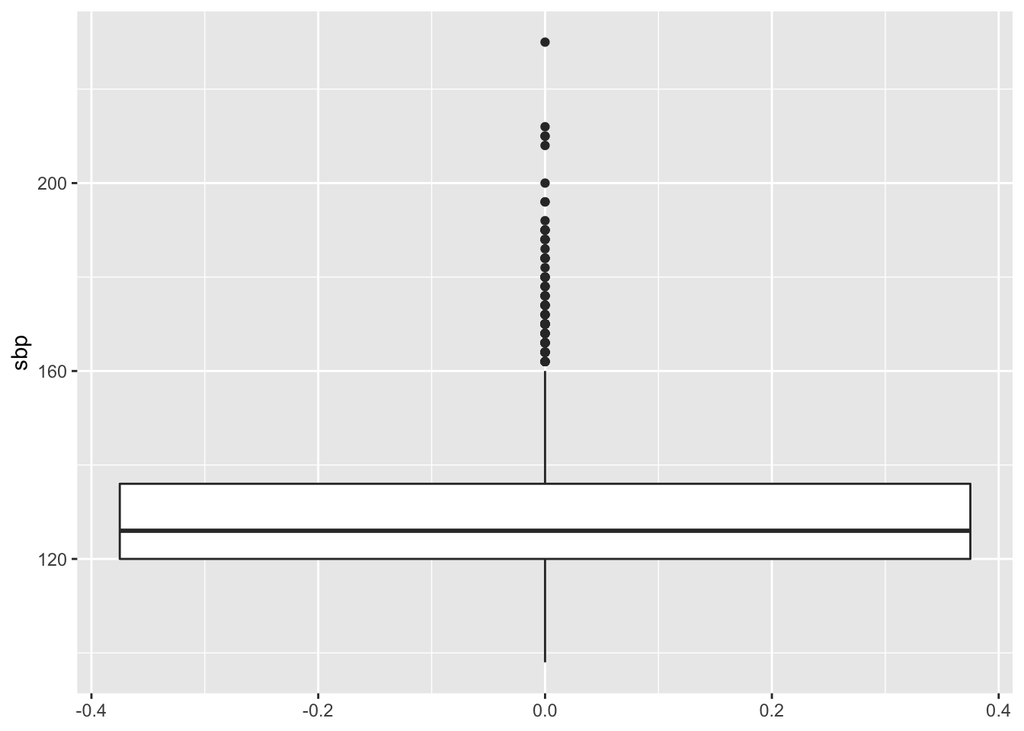

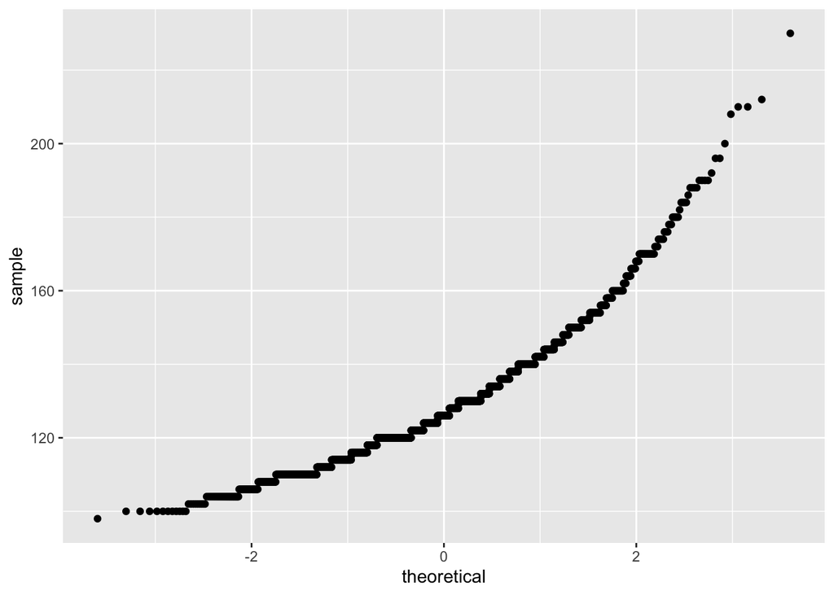

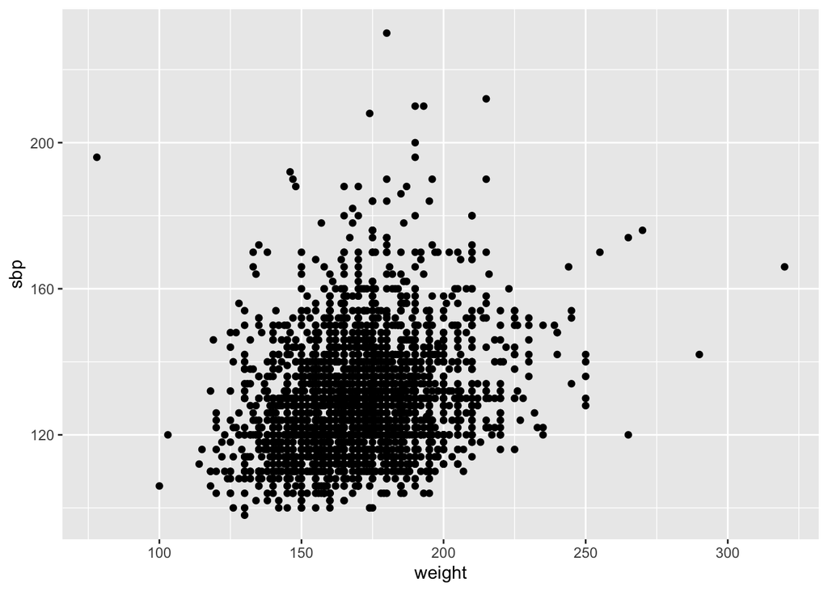

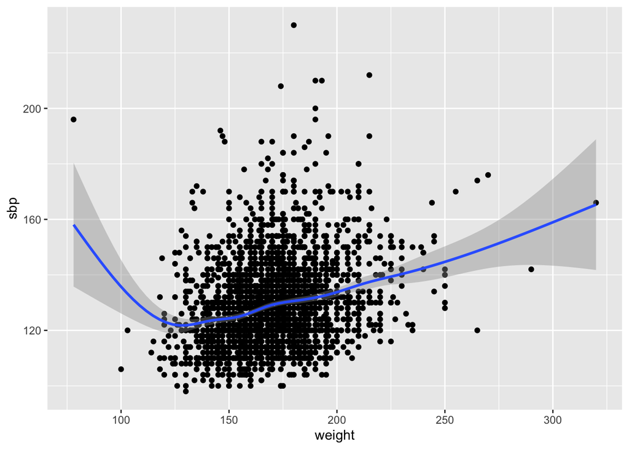